# My First Machine Learning Program

## Introduction

There is no better way to learn Machine Learning than to experiment with it! In this notebook you are step by step guided to do this. Challenge yourself in trying to understand the code and try to change the parameters.

First things first, we need a few libraries.

```python
import numpy as np
import pandas as pd
import sklearn as sk
import matplotlib
import matplotlib.pyplot as plt
from IPython.display import display

print('numpy version:', np.__version__)
print('pandas version:', pd.__version__)
print('scikit-learn version:', sk.__version__)
print('matplotlib version:', matplotlib.__version__)

%matplotlib inline
```

```
numpy version: 1.20.3
pandas version: 1.3.4
scikit-learn version: 0.24.2
matplotlib version: 3.4.3
```

The algorithm you are going to use is known as k-NN (k-Nearest Neighbors) classification.

## The supervised learning classification steps: overview

This notebook implements all specific tasks in applying supervised machine learning techniques:

- Preparing the data,
- Analysing and visualising the data,
- Cleaning the data,
- Selecting features,
- Dividing your data into a training and test set,
- Training and applying the machine learning algorithm,
- Evaluating its results.

You will learn more on how to do each task in the weeks to come. For now, try to read the code and experiment with it.

## Step 1 Preparing the data

The first step is to get the data. There are a lot of prepared datasets available on the internet. We've selected popular small dataset for you that are suitable for a classification.

### Downloading

```python
df_iris = pd.read_csv("http://archive.ics.uci.edu/ml/machine-learning-databases/iris/iris.data")
```

### Exploring the iris dataset

```python
df_iris.columns = ['Sepal Length', 'Sepal Width', 'Petal Length', 'Petal Width', 'Species']
print('Iris dataset shape: {}'.format(df_iris.shape))
df_iris.head(10)
```

```
Iris dataset shape: (149, 5)
```

|  | Sepal Length | Sepal Width | Petal Length | Petal Width | Species |
| --- | --- | --- | --- | --- | --- |
| 0 | 4.9 | 3.0 | 1.4 | 0.2 | Iris-setosa |
| 1 | 4.7 | 3.2 | 1.3 | 0.2 | Iris-setosa |
| 2 | 4.6 | 3.1 | 1.5 | 0.2 | Iris-setosa |
| 3 | 5.0 | 3.6 | 1.4 | 0.2 | Iris-setosa |
| 4 | 5.4 | 3.9 | 1.7 | 0.4 | Iris-setosa |
| 5 | 4.6 | 3.4 | 1.4 | 0.3 | Iris-setosa |
| 6 | 5.0 | 3.4 | 1.5 | 0.2 | Iris-setosa |
| 7 | 4.4 | 2.9 | 1.4 | 0.2 | Iris-setosa |
| 8 | 4.9 | 3.1 | 1.5 | 0.1 | Iris-setosa |
| 9 | 5.4 | 3.7 | 1.5 | 0.2 | Iris-setosa |

## Step 2 Analysing and visualising the data & cleaning the data

In this process the features should be stored in a 2D NxM array (matrix) variable separate from the label which should be stored in a 1D array (or vector) of size N. N (# rows) represents the number of data points or entries, M (# columns) represents the number of features.

#### Iris dataset

```python
df_iris['Species-id'] = df_iris['Species'].map({'Iris-setosa': 0, 'Iris-versicolor': 1, 'Iris-virginica': 2})
df_iris.sample(10)
```

|  | Sepal Length | Sepal Width | Petal Length | Petal Width | Species | Species-id |
| --- | --- | --- | --- | --- | --- | --- |
| 95 | 5.7 | 2.9 | 4.2 | 1.3 | Iris-versicolor | 1 |
| 78 | 5.7 | 2.6 | 3.5 | 1.0 | Iris-versicolor | 1 |
| 48 | 5.0 | 3.3 | 1.4 | 0.2 | Iris-setosa | 0 |
| 16 | 5.1 | 3.5 | 1.4 | 0.3 | Iris-setosa | 0 |
| 44 | 4.8 | 3.0 | 1.4 | 0.3 | Iris-setosa | 0 |
| 57 | 6.6 | 2.9 | 4.6 | 1.3 | Iris-versicolor | 1 |
| 144 | 6.7 | 3.0 | 5.2 | 2.3 | Iris-virginica | 2 |
| 32 | 5.5 | 4.2 | 1.4 | 0.2 | Iris-setosa | 0 |
| 93 | 5.6 | 2.7 | 4.2 | 1.3 | Iris-versicolor | 1 |
| 9 | 5.4 | 3.7 | 1.5 | 0.2 | Iris-setosa | 0 |

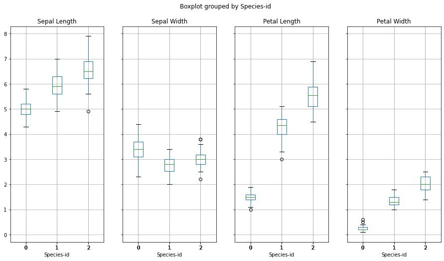

```python
iris_features = tuple(df_iris.columns[:4].values)
df_iris.boxplot(column=iris_features, by='Species-id', figsize=(15,8), layout=(1,4));
```

## Step 3 Cleaning the dataset

Since this dataset is already cleaned, we don't do anything here

## Step 4 Preprocesssing: Selecting features (and scaling them)

We will select two features and scale each feature linearly with standard scaler.

```python
from sklearn.preprocessing import StandardScaler
from sklearn.model_selection import train_test_split
from sklearn.svm import SVC
from sklearn import metrics
```

```
Iris types: [0 1 2]
```

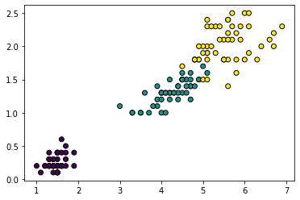

```python
# Define X_iris and y_iris
X_iris = df_iris[['Petal Length', 'Petal Width']]
y_iris = df_iris['Species-id']
print('Iris types:', df_iris['Species-id'].unique())
plt.scatter(X_iris['Petal Length'], X_iris['Petal Width'], edgecolors='k', c=y_iris)
```

```
The length of X_iris: 149
```

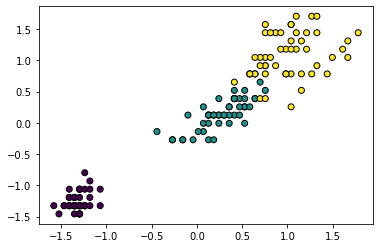

```python
# Normalize
scaler_iris = StandardScaler().fit(X_iris)
X_iris = scaler_iris.transform(X_iris)
print('The length of X_iris: {}'.format(len(X_iris)))
plt.scatter(X_iris[:,0], X_iris[:,1], edgecolors='k', c=y_iris)
```

## Step 5 Preprocessing: Dividing your data into a training and test set

Let’s use the symbol X for the scaled 2D input feature array, and the symbol y for the 1D output label vector. We will split the data into a train set and test set.

#### Iris dataset

```
Train shape: (111, 2) (111,)
Test shape: (38, 2) (38,)
```

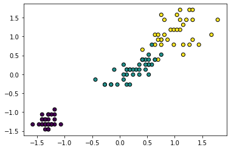

```python
# Split in train and test sets
X_train_iris, X_test_iris, y_train_iris, y_test_iris = train_test_split(X_iris, y_iris, test_size=0.25)
print('Train shape:', X_train_iris.shape, y_train_iris.shape)
print('Test shape:', X_test_iris.shape, y_test_iris.shape)

plt.scatter(X_train_iris[:,0], X_train_iris[:,1], edgecolors='k', c=y_train_iris)
```

## Step 6 Modeling: Training your Machine learning algorithm

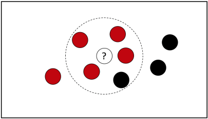

*Figure 1: A data point is classified by majority votes from its 5 nearest neighbors. Here, the unknown point would be classified as red, since 4 out of 5 neighbors are red.*

The library sklearn contains an implementation of the NearestNeighbors algorithm:

```python
from sklearn.neighbors import KNeighborsClassifier
```

```python
## we create an instance of Neighbours Classifier and fit the data.
clf_iris = KNeighborsClassifier(5)
clf_iris.fit(X_train_iris, y_train_iris)
```

```
KNeighborsClassifier()
```

## Step 7 Evaluation: Result of learning - accuracy

The accuracy of your KNN algorithm is based on the correct predicted labels of the hold-out test set.

#### Iris dataset

```python
#Evaluate performance (with test set)
print('Number of test points: ',X_test_iris.size)
y_pred_iris = clf_iris.predict(X_test_iris)
```

```
Number of test points:  76
```

Accuracy score for the Iris Dataset:

```python
metrics.accuracy_score(y_test_iris, y_pred_iris)
```

```
0.9473684210526315
```

```python
from sklearn.metrics import classification_report
target_names = ['class 0', 'class 1', 'class 2']
print(classification_report(y_test_iris, y_pred_iris, target_names=target_names))
```

```
              precision    recall  f1-score   support

     class 0       1.00      1.00      1.00        12
     class 1       0.82      1.00      0.90         9
     class 2       1.00      0.88      0.94        17

    accuracy                           0.95        38
   macro avg       0.94      0.96      0.95        38
weighted avg       0.96      0.95      0.95        38
```

## Now it is your turn

### Select another two features. Scale them with standard scaler. Plot the features with box plot. What do you observe?

For variety I will be using the Sepal Length and Width.  
I suspect that the accuracy using these attributes will be lower because the attributes have less severe variation between the classes.

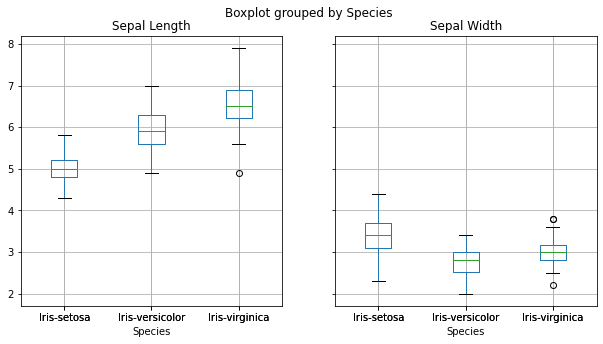

```python
df_iris.boxplot(
    column=tuple(df_iris.columns[:2]),
    # Species is not the attribute that should be used for the training but for readability it is used here
    by='Species',
    figsize=(10,5),
    layout=(1,2));
```

See what scatterplot looks like before standard scale and after.

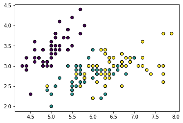

```python
irisAttributes = df_iris[['Sepal Length', 'Sepal Width']]
irisUniqueIdentifier = df_iris['Species-id']

plt.scatter(
    irisAttributes['Sepal Length'],
    irisAttributes['Sepal Width'],
    edgecolors='k',
    c=irisUniqueIdentifier)
```

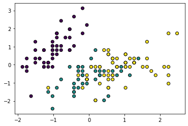

```python
irisAttributes = StandardScaler().fit(irisAttributes).transform(irisAttributes)
plt.scatter(
    irisAttributes[:,0],
    irisAttributes[:,1],
    edgecolors='k',
    c=irisUniqueIdentifier)
```

Species 2 and 3 are mostly entangled.  
This will cause the nearest neighbors algorithm to have a hard time figuring out which species it should pick and thus should have a higher % of miscategorizing.

### Divide your data into training and test data. Train your data with k nearst neighbour algorithm. Define k=5, and compare the accuracy with what you have obtained before. What do you observe?

Splitting the data and plotting the distributed data

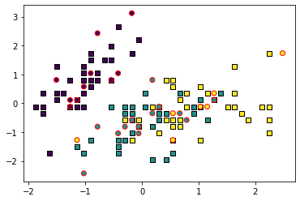

```python
irisAttributesTraining, irisAttributesTesting, irisUniqueIdentifierTraining, irisUniqueIdentifierTesting = train_test_split(irisAttributes, irisUniqueIdentifier, test_size=0.20, random_state=1)
plt.scatter(
    irisAttributesTraining[:,0],
    irisAttributesTraining[:,1],
    edgecolors='k',
    c=irisUniqueIdentifierTraining,
    marker='s')

# colors are not mapped based on the number itself so shifting the entries will not shift color
# def add_one(x):
#     return x + -1
# alternateColorArray = irisUniqueIdentifierTesting.apply(add_one)

plt.scatter(
    irisAttributesTesting[:,0],
    irisAttributesTesting[:,1],
    edgecolors='red',
    c=irisUniqueIdentifierTesting)
```

Training using k=5

```python
requiredNeighbors = 5
irisClassifier = KNeighborsClassifier(requiredNeighbors)
irisClassifier.fit(irisAttributesTraining, irisUniqueIdentifierTraining)

irisPrediction = irisClassifier.predict(irisAttributesTesting)
accuracyScoreDefaultK = metrics.accuracy_score(irisUniqueIdentifierTesting, irisPrediction)
print('Accuracy score with k=5: {}'.format(accuracyScoreDefaultK))
```

```
Accuracy score with k=5: 0.6
```

```python
classifications = ["class {}".format(i) for i in range(df_iris['Species-id'].nunique())]
print(classification_report(irisUniqueIdentifierTesting, irisPrediction, target_names=classifications))
```

```
              precision    recall  f1-score   support

     class 0       1.00      1.00      1.00        10
     class 1       0.57      0.31      0.40        13
     class 2       0.31      0.57      0.40         7

    accuracy                           0.60        30
   macro avg       0.63      0.63      0.60        30
weighted avg       0.65      0.60      0.60        30
```

### Try another k value and compare the accuracy. Compare your results with another student's. Are they the same? Why (not)?

```python
requiredNeighbors = 2
adjustedIrisClassifier = KNeighborsClassifier(requiredNeighbors)
adjustedIrisClassifier.fit(irisAttributesTraining, irisUniqueIdentifierTraining)

adjustedIrisPrediction = adjustedIrisClassifier.predict(irisAttributesTesting)
accuracyScoreDefaultK = metrics.accuracy_score(irisUniqueIdentifierTesting, adjustedIrisPrediction)
print('Accuracy score with k=2: {}'.format(accuracyScoreDefaultK))
print(classification_report(irisUniqueIdentifierTesting, adjustedIrisPrediction, target_names=classifications))
```

```
Accuracy score with k=2: 0.5333333333333333
              precision    recall  f1-score   support

     class 0       0.91      1.00      0.95        10
     class 1       0.45      0.38      0.42        13
     class 2       0.12      0.14      0.13         7

    accuracy                           0.53        30
   macro avg       0.50      0.51      0.50        30
weighted avg       0.53      0.53      0.53        30
```

using a k of 2 gives a lower accuracy score, this means that the algorithm is using less neighbors to determine the classification and had a higher likelyhood to pick neighbors that where of a different classification.

Keep in mind however that this is highly random and using a different seed for the training and testing distribution could flip this result just because the data given could be more or less favorable for this algorithm.

```python
adjustedIrisAttributesTraining, adjustedIrisAttributesTesting, adjustedIrisUniqueIdentifierTraining, adjustedIrisUniqueIdentifierTesting = train_test_split(irisAttributes, irisUniqueIdentifier, test_size=0.20, random_state=2)

irisPrediction = irisClassifier.predict(adjustedIrisAttributesTesting)
accuracyScoreDefaultK = metrics.accuracy_score(adjustedIrisUniqueIdentifierTesting, irisPrediction)
print('Accuracy score with k=5 and a different seed: {}'.format(accuracyScoreDefaultK))
print(classification_report(adjustedIrisUniqueIdentifierTesting, irisPrediction, target_names=classifications))
```

```
Accuracy score with k=5 and a different seed: 0.8666666666666667
              precision    recall  f1-score   support

     class 0       1.00      1.00      1.00        12
     class 1       0.86      0.67      0.75         9
     class 2       0.73      0.89      0.80         9

    accuracy                           0.87        30
   macro avg       0.86      0.85      0.85        30
weighted avg       0.88      0.87      0.86        30
```

### Optional: Find another data set from the same resource http://archive.ics.uci.edu/ml/machine-learning-databases and try out.